# UDACITY PROJECT 5 - FINAL PROJECT

## Data Exploration - Ford GoBike System Data Analysis

### *Jhonatan Nagasako*

#### *28-FEB-2021*

# Table of Contents (click link to section)

A. INTRODUCTION  
1. GATHERING DATA  
2. ASSESSING DATA  
3. CLEANING DATA  
4. STORING DATA

5. DATA EXPLORATION

- 5.1 [Exporation - Preliminary Review]
- 5.2 [Exporation - Univariate Exploration]
- 5.3 [Exporation - Bivariate Exploration]
- 5.4 [Exporation - Multivariate Exploration]

6. DISCUSSION

- 6.1 [Discussion - Preliminary Review]
- 6.2 [Discussion - Univariate Exploration]
- 6.3 [Discussion - Bivariate Exploration]
- 6.4 [Discussion - Multivariate Exploration]

7. CONCLUSION

*List of Figures - Detailed analysis to create plots and statistics (Click below)*

# A. INTRODUCTION

This notebook will focus on the **data EXPLORATION** of Ford GoBike System. Data source can be found via [Udacity provided link to Google Docs/Drive](https://docs.google.com/document/d/e/2PACX-1vQmkX4iOT6Rcrin42vslquX2_wQCjIa_hbwD0xmxrERPSOJYDtpNc_3wwK_p9_KpOsfA6QVyEHdxxq7/pub?embedded=True).

This data set includes information about individual rides made in a bike-sharing system covering the greater San Francisco Bay area.

- Note that this dataset will require some data wrangling in order to make it tidy for analysis. There are multiple cities covered by the linked system, and multiple data files will need to be joined together if a full year’s coverage is desired.
- Depending on scope of questions explored, additional data sources from other cities may be explored. Data can be accessed via [this page](https://www.google.com/url?q=https://www.bikeshare.com/data/&sa=D&source=editors&ust=1614518054096000&usg=AOvVaw38y_cueV0lTerb59CY7YsD) or [this page](https://www.google.com/url?q=https://github.com/BetaNYC/Bike-Share-Data-Best-Practices/wiki/Bike-Share-Data-Systems&sa=D&source=editors&ust=1614518054097000&usg=AOvVaw2OskG9ApXPoPZlezrpwmXp).

Questions to consider:

1. As a customer, when is it a good time to schedule a bike ride to avoid the rush (high influx of customers)?
2. As a shop owner, how should you strategically schedule your employees to ensure enough staff is present to assist customers?
3. As a shop owner, how can I exploit customer renting patterns to adjust prices of rides (e.g., bike-use-time/hr) or create discounts?

*The analysis endeavored below will address these questions, specifically in the conclusion section of this report*

[Table of Contents]

##### 📚 Gathering START -- Project START 📚

# 1. GATHERING DATA

[Table of Contents]

```python
# import statements for all of the packages used for analysis

import pandas as pd
import numpy as np
import matplotlib.pyplot as plt
import seaborn as sns
import statsmodels.api as sm;

# Remember to include a 'magic word' so that your visualizations are plotted
#   inline with the notebook. See this page for more:
#   http://ipython.readthedocs.io/en/stable/interactive/magics.html

%matplotlib inline
```

```python
# gather .csv file
df = pd.read_csv('201902-fordgobike-tripdata.csv')
df.head(3)
```

|  | duration_sec | start_time | end_time | start_station_id | start_station_name | start_station_latitude | start_station_longitude | end_station_id | end_station_name | end_station_latitude | end_station_longitude | bike_id | user_type | member_birth_year | member_gender | bike_share_for_all_trip |
| --- | --- | --- | --- | --- | --- | --- | --- | --- | --- | --- | --- | --- | --- | --- | --- | --- |
| 0 | 52185 | 2019-02-28 17:32:10.1450 | 2019-03-01 08:01:55.9750 | 21.0 | Montgomery St BART Station (Market St at 2nd St) | 37.789625 | -122.400811 | 13.0 | Commercial St at Montgomery St | 37.794231 | -122.402923 | 4902 | Customer | 1984.0 | Male | No |
| 1 | 42521 | 2019-02-28 18:53:21.7890 | 2019-03-01 06:42:03.0560 | 23.0 | The Embarcadero at Steuart St | 37.791464 | -122.391034 | 81.0 | Berry St at 4th St | 37.775880 | -122.393170 | 2535 | Customer | NaN | NaN | No |
| 2 | 61854 | 2019-02-28 12:13:13.2180 | 2019-03-01 05:24:08.1460 | 86.0 | Market St at Dolores St | 37.769305 | -122.426826 | 3.0 | Powell St BART Station (Market St at 4th St) | 37.786375 | -122.404904 | 5905 | Customer | 1972.0 | Male | No |

```python
# high-level overview of data shape and composition
print('\n----Shape of File (row, column)---\n')
print(df.shape)
print('\n----Data Types---\n')
print(df.dtypes)
print('\n----Unique Values---\n')
print(df.nunique())
print('\n----Number of missing values---\n')
print(df.isnull().sum())
```

```
----Shape of File (row, column)---

(183412, 16)

----Data Types---

duration_sec                 int64
start_time                  object
end_time                    object
start_station_id           float64
start_station_name          object
start_station_latitude     float64
start_station_longitude    float64
end_station_id             float64
end_station_name            object
end_station_latitude       float64
end_station_longitude      float64
bike_id                      int64
user_type                   object
member_birth_year          float64
member_gender               object
bike_share_for_all_trip     object
dtype: object

----Unique Values---

duration_sec                 4752
start_time                 183401
end_time                   183397
start_station_id              329
start_station_name            329
start_station_latitude        334
start_station_longitude       335
end_station_id                329
end_station_name              329
end_station_latitude          335
end_station_longitude         335
bike_id                      4646
user_type                       2
member_birth_year              75
```

[output cut: 8 more lines]

```
end_time                      0
start_station_id            197
start_station_name          197
start_station_latitude        0
start_station_longitude       0
end_station_id              197
end_station_name            197
end_station_latitude          0
end_station_longitude         0
bike_id                       0
user_type                     0
member_birth_year          8265
member_gender              8265
bike_share_for_all_trip       0
dtype: int64
```

##### 🔎 Gathering END ➜ Assessing START 🔎

# 2. ASSESSING DATA

[Table of Contents]

## QUALITY (click hyperlink question to go to section in notebook!)

[Go to QUALITY section]

✔️ 1. [Remove rows with ```NULL``` in ```end_station_id``` column (197 items)]

1. [Item above may fix this, but remove rows with ```NULL``` in thee following columns (197 items each)]
   - start_station_id
   - start_station_name
   - end_station_name
1. [Remove rows in ```start_station_latitude``` in ```start_station_longitude``` columns]
   - should change from 334-latitude and 335-longitude to 329 items
1. [Review ```member_birth_year``` and determine good cut-off date--remove rows respectively]
   - E.g., There is someone born in 1900 that rented a bike in 2019... that makes that person over 100 years old!
   - consider average age and oldest person... this could be errors that can be removed
1. [Convert ```duration_sec``` to minutes, hours, or/and days]

> **Tips for Common Data Quality Issues**
> 1. Missing data
> 2. Invalide data (e.g., state a negative height, or other datatype validation errors--str vs int vs float, think there can only be 2 people in a room... not 2.54 people in a room... *unless there's ghosts lol*)
> 3. Inaccurate data (e.g., specifying a foot = 5 inches, which is WRONG. A foot = 12 inches)
> 4. Inconsistent data (e.g., mixing up units, some data captured as cm instead of inches)

## TIDINESS

[Go to TIDY section]

1. [Create columns to break apart ```start_time``` to ```date``` and ```time```]
1. [Create columns to break apart ```end_time``` to ```date``` and ```time```]

> **Tips for Tidying**
> 1. Each variable forms a column.
> 2. Each observation forms a row.
> 3. Each type of observational unit forms a table *Reference for [tidy data here](https://cran.r-project.org/web/packages/tidyr/vignettes/tidy-data.html)*

## FEATURE ENGINEEERING

1. [Create column for ```day of week``` for the start/end days--to see what days bikes are rented the most]

[Assessing Data Requirements] [Table of Contents]

##### 🧹 Assessing END ➜ Cleaning START 🧹

# 3. CLEANING DATA

[Cleaning and Tidying To-do List] [Table of Contents]

## QUALITY ISSUES ADDRESSED -- note that `df` will change to `dfc` to indicate cleaned data

[Cleaning and Tidying To-do List]

### ✔️ 1. [Remove rows with ```NULL``` in ```end_station_id``` column (197 items)]

[Cleaning and Tidying To-do List]

```python
# before cleaning
print('\n----BEFORE CLEANING >> Number of missing values---\n')
print(df.isnull().sum())
print('\n----BEFORE CLEANING >> Shape of File (row, column)---\n')
print(df.shape)
```

```
----BEFORE CLEANING >> Number of missing values---

duration_sec                  0
start_time                    0
end_time                      0
start_station_id            197
start_station_name          197
start_station_latitude        0
start_station_longitude       0
end_station_id              197
end_station_name            197
end_station_latitude          0
end_station_longitude         0
bike_id                       0
user_type                     0
member_birth_year          8265
member_gender              8265
bike_share_for_all_trip       0
dtype: int64

----BEFORE CLEANING >> Shape of File (row, column)---

(183412, 16)
```

```python
# create test df for prototyping
test = df

# remove missing values
test.dropna(subset=['end_station_id'], inplace=True)
print('\n----AFTER CLEANING >> Number of missing values---\n')
print(df.isnull().sum())
print('\n----AFTER CLEANING >> Shape of File (row, column)---\n')
print(df.shape)
```

```
----AFTER CLEANING >> Number of missing values---

duration_sec                  0
start_time                    0
end_time                      0
start_station_id              0
start_station_name            0
start_station_latitude        0
start_station_longitude       0
end_station_id                0
end_station_name              0
end_station_latitude          0
end_station_longitude         0
bike_id                       0
user_type                     0
member_birth_year          8263
member_gender              8263
bike_share_for_all_trip       0
dtype: int64

----AFTER CLEANING >> Shape of File (row, column)---

(183215, 16)
```

```python
# reassign cleaned data to dfc
dfc = test
print(dfc.shape)
dfc.head(3)
```

```
(183215, 16)
```

|  | duration_sec | start_time | end_time | start_station_id | start_station_name | start_station_latitude | start_station_longitude | end_station_id | end_station_name | end_station_latitude | end_station_longitude | bike_id | user_type | member_birth_year | member_gender | bike_share_for_all_trip |
| --- | --- | --- | --- | --- | --- | --- | --- | --- | --- | --- | --- | --- | --- | --- | --- | --- |
| 0 | 52185 | 2019-02-28 17:32:10.1450 | 2019-03-01 08:01:55.9750 | 21.0 | Montgomery St BART Station (Market St at 2nd St) | 37.789625 | -122.400811 | 13.0 | Commercial St at Montgomery St | 37.794231 | -122.402923 | 4902 | Customer | 1984.0 | Male | No |
| 1 | 42521 | 2019-02-28 18:53:21.7890 | 2019-03-01 06:42:03.0560 | 23.0 | The Embarcadero at Steuart St | 37.791464 | -122.391034 | 81.0 | Berry St at 4th St | 37.775880 | -122.393170 | 2535 | Customer | NaN | NaN | No |
| 2 | 61854 | 2019-02-28 12:13:13.2180 | 2019-03-01 05:24:08.1460 | 86.0 | Market St at Dolores St | 37.769305 | -122.426826 | 3.0 | Powell St BART Station (Market St at 4th St) | 37.786375 | -122.404904 | 5905 | Customer | 1972.0 | Male | No |

*This process also removed the rows of missing information that was in the following columns:*

- `start_station_id`
- `start_station_name`
- `end_station_name`

### ✔️ 2. [Item above may fix this, but remove rows with ```NULL``` in thee following columns (197 items each)]

```
* start_station_id
* start_station_name
* end_station_name
```

[Cleaning and Tidying To-do List]

*See section (Quality Question Task Q1) for the removal of the missing values.*

### ✔️ 3. [Remove rows in ```start_station_latitude``` in ```start_station_longitude``` columns]

```
* should change from 334-latitude and 335-longitude to 329 items
```

[Cleaning and Tidying To-do List]

*See section (Quality Question Task Q1) for the removal of the missing values.*

### ✔️ 4. [Review ```member_birth_year``` and determine good cut-off date--remove rows respectively]

[Cleaning and Tidying To-do List]

```python
# high-level overview of data shape and composition
print('\n----INITIAL STATE > Shape of File (row, column)---\n')
print(dfc.shape)
print('\n----INITIAL STATE > Data Types---\n')
print(dfc.dtypes)
print('\n----INITIAL STATE > Unique Values---\n')
print(dfc.nunique())
print('\n----INITIAL STATE > Number of missing values---\n')
print(dfc.isnull().sum())
```

```
----INITIAL STATE > Shape of File (row, column)---

(183215, 16)

----INITIAL STATE > Data Types---

duration_sec                 int64
start_time                  object
end_time                    object
start_station_id           float64
start_station_name          object
start_station_latitude     float64
start_station_longitude    float64
end_station_id             float64
end_station_name            object
end_station_latitude       float64
end_station_longitude      float64
bike_id                      int64
user_type                   object
member_birth_year          float64
member_gender               object
bike_share_for_all_trip     object
dtype: object

----INITIAL STATE > Unique Values---

duration_sec                 4749
start_time                 183204
end_time                   183200
start_station_id              329
start_station_name            329
start_station_latitude        329
start_station_longitude       329
end_station_id                329
end_station_name              329
end_station_latitude          329
end_station_longitude         329
bike_id                      4618
user_type                       2
member_birth_year              75
```

[output cut: 8 more lines]

```
end_time                      0
start_station_id              0
start_station_name            0
start_station_latitude        0
start_station_longitude       0
end_station_id                0
end_station_name              0
end_station_latitude          0
end_station_longitude         0
bike_id                       0
user_type                     0
member_birth_year          8263
member_gender              8263
bike_share_for_all_trip       0
dtype: int64
```

```python
# create test df for prototyping
test = dfc

# need to fill blank locations in order to change the data type
test = test.fillna(0)

# change member_birth_year from FLOAT to INT
test['member_birth_year'] = test['member_birth_year'].astype(int)

print('\n----CLEANED STATE > Shape of File (row, column)---\n')
print(test.shape)
print('\n----CLEANED STATE > Data Types---\n')
print(test.dtypes)
print('\n----CLEANED STATE > Unique Values---\n')
print(test.nunique())
print('\n----CLEANED STATE > Number of missing values---\n')
print(test.isnull().sum())
```

```
----CLEANED STATE > Shape of File (row, column)---

(183215, 16)

----CLEANED STATE > Data Types---

duration_sec                 int64
start_time                  object
end_time                    object
start_station_id           float64
start_station_name          object
start_station_latitude     float64
start_station_longitude    float64
end_station_id             float64
end_station_name            object
end_station_latitude       float64
end_station_longitude      float64
bike_id                      int64
user_type                   object
member_birth_year            int32
member_gender               object
bike_share_for_all_trip     object
dtype: object

----CLEANED STATE > Unique Values---

duration_sec                 4749
start_time                 183204
end_time                   183200
start_station_id              329
start_station_name            329
start_station_latitude        329
start_station_longitude       329
end_station_id                329
end_station_name              329
end_station_latitude          329
end_station_longitude         329
bike_id                      4618
user_type                       2
member_birth_year              76
```

[output cut: 8 more lines]

```
end_time                   0
start_station_id           0
start_station_name         0
start_station_latitude     0
start_station_longitude    0
end_station_id             0
end_station_name           0
end_station_latitude       0
end_station_longitude      0
bike_id                    0
user_type                  0
member_birth_year          0
member_gender              0
bike_share_for_all_trip    0
dtype: int64
```

*Removing the missing values in the `member_birth_year` also removed missing values in `member_gender`*

Determine good cutoff range, note that the data set is from 02-FEB-2019.

- [Oldest person alive](https://www.google.com/search?q=oldest+person+alive&rlz=1C1GCEB_enUS893US893&oq=oldest+person&aqs=chrome.0.0i433j69i57j0l2j0i67j0l5.3255j0j7&sourceid=chrome&ie=UTF-8) is **118**

After the review of the [2010 U.S. Census Bureu](https://www.census.gov/prod/cen2010/briefs/c2010br-03.pdf), lets make *age 100* the cut off point when considering age and gender.

```python
# create column for age (based on 2019)
test['age'] = 2019 - test['member_birth_year']

# help: https://datascience.stackexchange.com/questions/38720/shifting-the-last-column-in-the-dataframe-to-the-first-place
# move last column to first temporarily
cols = list(test.columns)
cols = [cols[-1]] + cols[:-1]
test = test[cols]

#display data before filtering
test1 = test
print('BEFORE FILTER - Basic Stats on AGE\n', test.age.describe())
print('\nBEFORE FILTER, Zero Count = ',test1.age.isin([0]).sum())
test.head(2)
```

```
BEFORE FILTER - Basic Stats on AGE
 count    183215.000000
mean        123.711525
std         412.013105
min          18.000000
25%          27.000000
50%          32.000000
75%          40.000000
max        2019.000000
Name: age, dtype: float64

BEFORE FILTER, Zero Count =  0
```

|  | age | duration_sec | start_time | end_time | start_station_id | start_station_name | start_station_latitude | start_station_longitude | end_station_id | end_station_name | end_station_latitude | end_station_longitude | bike_id | user_type | member_birth_year | member_gender | bike_share_for_all_trip |
| --- | --- | --- | --- | --- | --- | --- | --- | --- | --- | --- | --- | --- | --- | --- | --- | --- | --- |
| 0 | 35 | 52185 | 2019-02-28 17:32:10.1450 | 2019-03-01 08:01:55.9750 | 21.0 | Montgomery St BART Station (Market St at 2nd St) | 37.789625 | -122.400811 | 13.0 | Commercial St at Montgomery St | 37.794231 | -122.402923 | 4902 | Customer | 1984 | Male | No |
| 1 | 2019 | 42521 | 2019-02-28 18:53:21.7890 | 2019-03-01 06:42:03.0560 | 23.0 | The Embarcadero at Steuart St | 37.791464 | -122.391034 | 81.0 | Berry St at 4th St | 37.775880 | -122.393170 | 2535 | Customer | 0 | 0 | No |

```python
# replace any values greater than 100 with zeros -- data set should remain the same
test['age'].values[test['age'].values > 100] = 0

# review age statitics distrubtion
print('AFTER FILTER - Basic Stats on AGE\n', test.age.describe())
print('\nAFTER FILTER, Zero Count in AGE column = ',test1.age.isin([0]).sum())
test.head(2)
```

```
AFTER FILTER - Basic Stats on AGE
 count    183215.000000
mean         32.607909
std          12.067822
min           0.000000
25%          26.000000
50%          31.000000
75%          38.000000
max          99.000000
Name: age, dtype: float64

AFTER FILTER, Zero Count in AGE column =  8335
```

|  | age | duration_sec | start_time | end_time | start_station_id | start_station_name | start_station_latitude | start_station_longitude | end_station_id | end_station_name | end_station_latitude | end_station_longitude | bike_id | user_type | member_birth_year | member_gender | bike_share_for_all_trip |
| --- | --- | --- | --- | --- | --- | --- | --- | --- | --- | --- | --- | --- | --- | --- | --- | --- | --- |
| 0 | 35 | 52185 | 2019-02-28 17:32:10.1450 | 2019-03-01 08:01:55.9750 | 21.0 | Montgomery St BART Station (Market St at 2nd St) | 37.789625 | -122.400811 | 13.0 | Commercial St at Montgomery St | 37.794231 | -122.402923 | 4902 | Customer | 1984 | Male | No |
| 1 | 0 | 42521 | 2019-02-28 18:53:21.7890 | 2019-03-01 06:42:03.0560 | 23.0 | The Embarcadero at Steuart St | 37.791464 | -122.391034 | 81.0 | Berry St at 4th St | 37.775880 | -122.393170 | 2535 | Customer | 0 | 0 | No |

Knowing the number of ZEROS in the `AGE` column may be important to consider when taking the mean or median (e.g., stats) of the dataframe. These ZEROS may need to be filtered/removed to ensure proper stats are completed with entries with acutal data.

Note we replaced all BLANKS with ZEROS earlier in the code.

```python
# help: https://cmdlinetips.com/2020/03/move-a-column-to-first-position-in-pandas-dataframe/
# moving age next to member_birth_year
col_name="age"
first_col = test.pop(col_name)
test.insert(14, col_name, first_col)
test.head(2)
```

|  | duration_sec | start_time | end_time | start_station_id | start_station_name | start_station_latitude | start_station_longitude | end_station_id | end_station_name | end_station_latitude | end_station_longitude | bike_id | user_type | member_birth_year | age | member_gender | bike_share_for_all_trip |
| --- | --- | --- | --- | --- | --- | --- | --- | --- | --- | --- | --- | --- | --- | --- | --- | --- | --- |
| 0 | 52185 | 2019-02-28 17:32:10.1450 | 2019-03-01 08:01:55.9750 | 21.0 | Montgomery St BART Station (Market St at 2nd St) | 37.789625 | -122.400811 | 13.0 | Commercial St at Montgomery St | 37.794231 | -122.402923 | 4902 | Customer | 1984 | 35 | Male | No |
| 1 | 42521 | 2019-02-28 18:53:21.7890 | 2019-03-01 06:42:03.0560 | 23.0 | The Embarcadero at Steuart St | 37.791464 | -122.391034 | 81.0 | Berry St at 4th St | 37.775880 | -122.393170 | 2535 | Customer | 0 | 0 | 0 | No |

```python
# make test df into dfc again
dfc = test
dfc.head(2)
```

|  | duration_sec | start_time | end_time | start_station_id | start_station_name | start_station_latitude | start_station_longitude | end_station_id | end_station_name | end_station_latitude | end_station_longitude | bike_id | user_type | member_birth_year | age | member_gender | bike_share_for_all_trip |
| --- | --- | --- | --- | --- | --- | --- | --- | --- | --- | --- | --- | --- | --- | --- | --- | --- | --- |
| 0 | 52185 | 2019-02-28 17:32:10.1450 | 2019-03-01 08:01:55.9750 | 21.0 | Montgomery St BART Station (Market St at 2nd St) | 37.789625 | -122.400811 | 13.0 | Commercial St at Montgomery St | 37.794231 | -122.402923 | 4902 | Customer | 1984 | 35 | Male | No |
| 1 | 42521 | 2019-02-28 18:53:21.7890 | 2019-03-01 06:42:03.0560 | 23.0 | The Embarcadero at Steuart St | 37.791464 | -122.391034 | 81.0 | Berry St at 4th St | 37.775880 | -122.393170 | 2535 | Customer | 0 | 0 | 0 | No |

### ✔️ 5. [Convert ```duration_sec``` to minutes, hours, or/and days]

[Cleaning and Tidying To-do List]

```python
# help: https://stackoverflow.com/questions/45579525/returning-a-dataframe-in-python-function/48368668
# preventing memory lost of df created in function

def firstLast(dataframe):
    cols = list(dataframe.columns)
    cols = [cols[-1]] + cols[:-1]
    dataframe = dataframe[cols]
    return dataframe

def timeConvertion(dataframe, seconds):
    dataframe['duration_min'] = dataframe[seconds] / 60
    dataframe = firstLast(dataframe) # save the dataframe within the function so it is not removed from memory
    dataframe['duration_hr'] = dataframe['duration_min'] / 60
    dataframe = firstLast(dataframe)
    return dataframe

test = dfc

test1 = timeConvertion(test, 'duration_sec')

test1.head(2)
```

|  | duration_hr | duration_min | duration_sec | start_time | end_time | start_station_id | start_station_name | start_station_latitude | start_station_longitude | end_station_id | end_station_name | end_station_latitude | end_station_longitude | bike_id | user_type | member_birth_year | age | member_gender | bike_share_for_all_trip |
| --- | --- | --- | --- | --- | --- | --- | --- | --- | --- | --- | --- | --- | --- | --- | --- | --- | --- | --- | --- |
| 0 | 14.495833 | 869.750000 | 52185 | 2019-02-28 17:32:10.1450 | 2019-03-01 08:01:55.9750 | 21.0 | Montgomery St BART Station (Market St at 2nd St) | 37.789625 | -122.400811 | 13.0 | Commercial St at Montgomery St | 37.794231 | -122.402923 | 4902 | Customer | 1984 | 35 | Male | No |
| 1 | 11.811389 | 708.683333 | 42521 | 2019-02-28 18:53:21.7890 | 2019-03-01 06:42:03.0560 | 23.0 | The Embarcadero at Steuart St | 37.791464 | -122.391034 | 81.0 | Berry St at 4th St | 37.775880 | -122.393170 | 2535 | Customer | 0 | 0 | 0 | No |

```python
# assign prototype df to clean df
dfc = test1
dfc.head(2)
```

|  | duration_hr | duration_min | duration_sec | start_time | end_time | start_station_id | start_station_name | start_station_latitude | start_station_longitude | end_station_id | end_station_name | end_station_latitude | end_station_longitude | bike_id | user_type | member_birth_year | age | member_gender | bike_share_for_all_trip |
| --- | --- | --- | --- | --- | --- | --- | --- | --- | --- | --- | --- | --- | --- | --- | --- | --- | --- | --- | --- |
| 0 | 14.495833 | 869.750000 | 52185 | 2019-02-28 17:32:10.1450 | 2019-03-01 08:01:55.9750 | 21.0 | Montgomery St BART Station (Market St at 2nd St) | 37.789625 | -122.400811 | 13.0 | Commercial St at Montgomery St | 37.794231 | -122.402923 | 4902 | Customer | 1984 | 35 | Male | No |
| 1 | 11.811389 | 708.683333 | 42521 | 2019-02-28 18:53:21.7890 | 2019-03-01 06:42:03.0560 | 23.0 | The Embarcadero at Steuart St | 37.791464 | -122.391034 | 81.0 | Berry St at 4th St | 37.775880 | -122.393170 | 2535 | Customer | 0 | 0 | 0 | No |

## TIDINESS ISSUES ADDRESSED -- note that `df` will change to `dfc` to indicate cleaned data

[Cleaning Data Requirements] [Cleaning and Tidying To-do List] [Table of Contents]

### ✔️ 1. [Create columns to break apart ```start_time``` to ```date``` and ```time```]

[Cleaning and Tidying To-do List]

The function `firstLast` can be found earlier in the code.

```python
def dateSeperator(dataframe, start, end):
    dataframe[end] = pd.to_datetime(dataframe[end])

    dataframe['end_hour'] = dataframe[end].dt.time
    dataframe = firstLast(dataframe)

    dataframe[start] = pd.to_datetime(dataframe[start])
    dataframe['start_hour'] = dataframe[start].dt.time
    dataframe = firstLast(dataframe)

    dataframe[end] = pd.to_datetime(dataframe[end])
    dataframe['end_day'] = dataframe[end].dt.date
    dataframe = firstLast(dataframe)

    dataframe[start] = pd.to_datetime(dataframe[start])
    dataframe['start_day'] = dataframe[start].dt.date
    dataframe = firstLast(dataframe)

    return dataframe

test = dfc

test1 = dateSeperator(test, 'start_time', 'end_time')

test1.head(2)
```

|  | start_day | end_day | start_hour | end_hour | duration_hr | duration_min | duration_sec | start_time | end_time | start_station_id | ... | end_station_id | end_station_name | end_station_latitude | end_station_longitude | bike_id | user_type | member_birth_year | age | member_gender | bike_share_for_all_trip |
| --- | --- | --- | --- | --- | --- | --- | --- | --- | --- | --- | --- | --- | --- | --- | --- | --- | --- | --- | --- | --- | --- |
| 0 | 2019-02-28 | 2019-03-01 | 17:32:10.145000 | 08:01:55.975000 | 14.495833 | 869.750000 | 52185 | 2019-02-28 17:32:10.145 | 2019-03-01 08:01:55.975 | 21.0 | ... | 13.0 | Commercial St at Montgomery St | 37.794231 | -122.402923 | 4902 | Customer | 1984 | 35 | Male | No |
| 1 | 2019-02-28 | 2019-03-01 | 18:53:21.789000 | 06:42:03.056000 | 11.811389 | 708.683333 | 42521 | 2019-02-28 18:53:21.789 | 2019-03-01 06:42:03.056 | 23.0 | ... | 81.0 | Berry St at 4th St | 37.775880 | -122.393170 | 2535 | Customer | 0 | 0 | 0 | No |

2 rows × 23 columns

```python
# recorganize data and check data type

# help: https://cmdlinetips.com/2020/03/move-a-column-to-first-position-in-pandas-dataframe/
col_name="start_time"
first_col = test1.pop(col_name)
test1.insert(4, col_name, first_col)

col_name="end_time"
first_col = test1.pop(col_name)
test1.insert(5, col_name, first_col)

test1.head(2)
```

|  | start_day | end_day | start_hour | end_hour | start_time | end_time | duration_hr | duration_min | duration_sec | start_station_id | ... | end_station_id | end_station_name | end_station_latitude | end_station_longitude | bike_id | user_type | member_birth_year | age | member_gender | bike_share_for_all_trip |
| --- | --- | --- | --- | --- | --- | --- | --- | --- | --- | --- | --- | --- | --- | --- | --- | --- | --- | --- | --- | --- | --- |
| 0 | 2019-02-28 | 2019-03-01 | 17:32:10.145000 | 08:01:55.975000 | 2019-02-28 17:32:10.145 | 2019-03-01 08:01:55.975 | 14.495833 | 869.750000 | 52185 | 21.0 | ... | 13.0 | Commercial St at Montgomery St | 37.794231 | -122.402923 | 4902 | Customer | 1984 | 35 | Male | No |
| 1 | 2019-02-28 | 2019-03-01 | 18:53:21.789000 | 06:42:03.056000 | 2019-02-28 18:53:21.789 | 2019-03-01 06:42:03.056 | 11.811389 | 708.683333 | 42521 | 23.0 | ... | 81.0 | Berry St at 4th St | 37.775880 | -122.393170 | 2535 | Customer | 0 | 0 | 0 | No |

2 rows × 23 columns

The function `firstLast` can be found earlier in the code.

```python
# help: https://stackoverflow.com/questions/30222533/create-a-day-of-week-column-in-a-pandas-dataframe-using-python

def dayOfWeek(dataframe, start, end):

    dataframe[end] = pd.to_datetime(dataframe[end])
    dataframe['end_day_of_week'] = dataframe[end].dt.dayofweek
    dataframe = firstLast(dataframe)

    dataframe[start] = pd.to_datetime(dataframe[start])
    dataframe['start_day_of_week'] = dataframe[start].dt.dayofweek
    dataframe = firstLast(dataframe)

    days = {0:'MON',1:'TUE',2:'WED',3:'THU',4:'FRI',5:'SAT',6:'SUN'}

    # look up day dictionary for day of week
    dataframe['end_day_of_week'] = dataframe['end_day_of_week'].apply(lambda x: days[x])
    dataframe['start_day_of_week'] = dataframe['start_day_of_week'].apply(lambda x: days[x])

    return dataframe


test2 = dayOfWeek(test1, 'start_time', 'end_time')

#print('distribution day of week\n', test2.groupby['start_day_of_week'].count())

count = test2.groupby('start_day_of_week')['start_time'].count().sort_values(ascending=False)
count1 = test2.groupby('end_day_of_week')['end_time'].count().sort_values(ascending=False)

print('START day of the week count\n', count)
print('\nEND day of the week count\n', count1)
test2.head(2)
```

```
START day of the week count
 start_day_of_week
THU    35176
TUE    31781
WED    29609
FRI    28962
MON    26807
SUN    15503
SAT    15377
Name: start_time, dtype: int64

END day of the week count
 end_day_of_week
THU    35164
TUE    31788
WED    29599
FRI    28962
MON    26814
SUN    15503
SAT    15385
Name: end_time, dtype: int64
```

|  | start_day_of_week | end_day_of_week | start_day | end_day | start_hour | end_hour | start_time | end_time | duration_hr | duration_min | ... | end_station_id | end_station_name | end_station_latitude | end_station_longitude | bike_id | user_type | member_birth_year | age | member_gender | bike_share_for_all_trip |
| --- | --- | --- | --- | --- | --- | --- | --- | --- | --- | --- | --- | --- | --- | --- | --- | --- | --- | --- | --- | --- | --- |
| 0 | THU | FRI | 2019-02-28 | 2019-03-01 | 17:32:10.145000 | 08:01:55.975000 | 2019-02-28 17:32:10.145 | 2019-03-01 08:01:55.975 | 14.495833 | 869.750000 | ... | 13.0 | Commercial St at Montgomery St | 37.794231 | -122.402923 | 4902 | Customer | 1984 | 35 | Male | No |
| 1 | THU | FRI | 2019-02-28 | 2019-03-01 | 18:53:21.789000 | 06:42:03.056000 | 2019-02-28 18:53:21.789 | 2019-03-01 06:42:03.056 | 11.811389 | 708.683333 | ... | 81.0 | Berry St at 4th St | 37.775880 | -122.393170 | 2535 | Customer | 0 | 0 | 0 | No |

2 rows × 25 columns

```python
# help: https://stackoverflow.com/questions/30222533/create-a-day-of-week-column-in-a-pandas-dataframe-using-python
# also help for month: https://pandas.pydata.org/pandas-docs/stable/reference/api/pandas.Series.dt.month.html

def dayOfMonth(dataframe, start, end):

    dataframe[end] = pd.to_datetime(dataframe[end])
    dataframe['end_month'] = dataframe[end].dt.month
    dataframe = firstLast(dataframe)

    dataframe[start] = pd.to_datetime(dataframe[start])
    dataframe['start_month'] = dataframe[start].dt.month
    dataframe = firstLast(dataframe)

    months = {1:'JAN',2:'FEB',3:'MAR',4:'APR',5:'MAY',6:'JUN',7:'JUL',8:'AUG',9:'SEP',10:'OCT',11:'NOV',12:'DEC'}

    # look up day dictionary for day of week
    dataframe['end_month'] = dataframe['end_month'].apply(lambda x: months[x])
    dataframe['start_month'] = dataframe['start_month'].apply(lambda x: months[x])

    return dataframe


test3 = dayOfMonth(test2, 'start_time', 'end_time')

#print('distribution day of week\n', test2.groupby['start_day_of_week'].count())

count = test3.groupby('start_month')['start_time'].count().sort_values(ascending=False)
count1 = test3.groupby('end_month')['end_time'].count().sort_values(ascending=False)

print('START day of the week count\n', count)
print('\nEND day of the week count\n', count1)
test3.head(2)
```

```
START day of the week count
 start_month
FEB    183215
Name: start_time, dtype: int64

END day of the week count
 end_month
FEB    183199
MAR        16
Name: end_time, dtype: int64
```

|  | start_month | end_month | start_day_of_week | end_day_of_week | start_day | end_day | start_hour | end_hour | start_time | end_time | ... | end_station_id | end_station_name | end_station_latitude | end_station_longitude | bike_id | user_type | member_birth_year | age | member_gender | bike_share_for_all_trip |
| --- | --- | --- | --- | --- | --- | --- | --- | --- | --- | --- | --- | --- | --- | --- | --- | --- | --- | --- | --- | --- | --- |
| 0 | FEB | MAR | THU | FRI | 2019-02-28 | 2019-03-01 | 17:32:10.145000 | 08:01:55.975000 | 2019-02-28 17:32:10.145 | 2019-03-01 08:01:55.975 | ... | 13.0 | Commercial St at Montgomery St | 37.794231 | -122.402923 | 4902 | Customer | 1984 | 35 | Male | No |
| 1 | FEB | MAR | THU | FRI | 2019-02-28 | 2019-03-01 | 18:53:21.789000 | 06:42:03.056000 | 2019-02-28 18:53:21.789 | 2019-03-01 06:42:03.056 | ... | 81.0 | Berry St at 4th St | 37.775880 | -122.393170 | 2535 | Customer | 0 | 0 | 0 | No |

2 rows × 27 columns

```python
print('\n----CLEANED STATE > Shape of File (row, column)---\n')
print(test3.shape)
print('\n----CLEANED STATE > Data Types---\n')
print(test3.dtypes)
print('\n----CLEANED STATE > Unique Values---\n')
print(test3.nunique())
print('\n----CLEANED STATE > Number of missing values---\n')
print(test3.isnull().sum())
```

```
----CLEANED STATE > Shape of File (row, column)---

(183215, 27)

----CLEANED STATE > Data Types---

start_month                        object
end_month                          object
start_day_of_week                  object
end_day_of_week                    object
start_day                          object
end_day                            object
start_hour                         object
end_hour                           object
start_time                 datetime64[ns]
end_time                   datetime64[ns]
duration_hr                       float64
duration_min                      float64
duration_sec                        int64
start_station_id                  float64
start_station_name                 object
start_station_latitude            float64
start_station_longitude           float64
end_station_id                    float64
end_station_name                   object
end_station_latitude              float64
end_station_longitude             float64
bike_id                             int64
user_type                          object
member_birth_year                   int32
age                                 int32
member_gender                      object
bike_share_for_all_trip            object
dtype: object

----CLEANED STATE > Unique Values---

start_month                     1
end_month                       2
start_day_of_week               7
```

[output cut: 41 more lines]

```
start_station_id           0
start_station_name         0
start_station_latitude     0
start_station_longitude    0
end_station_id             0
end_station_name           0
end_station_latitude       0
end_station_longitude      0
bike_id                    0
user_type                  0
member_birth_year          0
age                        0
member_gender              0
bike_share_for_all_trip    0
dtype: int64
```

```python
# reassign the df to dfc
dfc = test3
dfc.head(2)
```

|  | start_month | end_month | start_day_of_week | end_day_of_week | start_day | end_day | start_hour | end_hour | start_time | end_time | ... | end_station_id | end_station_name | end_station_latitude | end_station_longitude | bike_id | user_type | member_birth_year | age | member_gender | bike_share_for_all_trip |
| --- | --- | --- | --- | --- | --- | --- | --- | --- | --- | --- | --- | --- | --- | --- | --- | --- | --- | --- | --- | --- | --- |
| 0 | FEB | MAR | THU | FRI | 2019-02-28 | 2019-03-01 | 17:32:10.145000 | 08:01:55.975000 | 2019-02-28 17:32:10.145 | 2019-03-01 08:01:55.975 | ... | 13.0 | Commercial St at Montgomery St | 37.794231 | -122.402923 | 4902 | Customer | 1984 | 35 | Male | No |
| 1 | FEB | MAR | THU | FRI | 2019-02-28 | 2019-03-01 | 18:53:21.789000 | 06:42:03.056000 | 2019-02-28 18:53:21.789 | 2019-03-01 06:42:03.056 | ... | 81.0 | Berry St at 4th St | 37.775880 | -122.393170 | 2535 | Customer | 0 | 0 | 0 | No |

2 rows × 27 columns

### ✔️ 2. [Create columns to break apart ```end_time``` to ```date``` and ```time```]

[Cleaning and Tidying To-do List]

*This was solved in Tidy Question 1 (above).*

##### 💾 Cleaning END ➜ Storing START 💾

# 4. STORING

[Table of Contents]

```python
# create csv from master dataframe - warning to user that opening these files "may" cause viewing software to crash
# help: https://www.guru99.com/python-check-if-file-exists.html

import os.path
from os import path
fileFlag1 = False # initilized as FALSE -- assuming .csv files have not be created from dataframes in this notebook
```

```python
# help: https://www.geeksforgeeks.org/g-fact-41-multiple-return-values-in-python/
def createCSVmaster():
    # adding "1-" can for easier file handling in folder
    dfc.to_csv('master.csv', index=False)
    fileFlag1 = True
    print('master.csv File created ... Ready for user data analysis')
    return fileFlag1

if path.exists('master.csv') == True:
    print("File aready created! ... Ready for user data analysis")
elif fileFlag1 == False:
    fileFlag1 = createCSVmaster() # Assign returned tuple , execute file create assuming fileFlag1 is FALSE (has not be done)
else:
    assert path.exists('master.csv') == True, "You need to create the master.csv file"
    print("Files exists! ... Ready for user data analysis")

# could add button here for "confirmation" data was reviewed
```

```
File aready created! ... Ready for user data analysis
```

##### 🗺️ Storing END ➜ Data Exploration START 🗺️

# 5. DATA EXPLORATION

[Table of Contents]

[#5 Data Exporation]  
--- [Preliminary Review] --- [Univariate Exploration] --- [Bivariate Exploration] --- [Multivariate Exploration]

[#6 Discussion]  
--- [Preliminary Review] --- [Univariate Exploration] --- [Bivariate Exploration] --- [Multivariate Exploration]

```python
# csv read into notebook again

df = pd.read_csv('master.csv')
df.head(3)
```

|  | start_month | end_month | start_day_of_week | end_day_of_week | start_day | end_day | start_hour | end_hour | start_time | end_time | ... | end_station_id | end_station_name | end_station_latitude | end_station_longitude | bike_id | user_type | member_birth_year | age | member_gender | bike_share_for_all_trip |
| --- | --- | --- | --- | --- | --- | --- | --- | --- | --- | --- | --- | --- | --- | --- | --- | --- | --- | --- | --- | --- | --- |
| 0 | FEB | MAR | THU | FRI | 2019-02-28 | 2019-03-01 | 17:32:10.145000 | 08:01:55.975000 | 2019-02-28 17:32:10.145 | 2019-03-01 08:01:55.975 | ... | 13.0 | Commercial St at Montgomery St | 37.794231 | -122.402923 | 4902 | Customer | 1984 | 35 | Male | No |
| 1 | FEB | MAR | THU | FRI | 2019-02-28 | 2019-03-01 | 18:53:21.789000 | 06:42:03.056000 | 2019-02-28 18:53:21.789 | 2019-03-01 06:42:03.056 | ... | 81.0 | Berry St at 4th St | 37.775880 | -122.393170 | 2535 | Customer | 0 | 0 | 0 | No |
| 2 | FEB | MAR | THU | FRI | 2019-02-28 | 2019-03-01 | 12:13:13.218000 | 05:24:08.146000 | 2019-02-28 12:13:13.218 | 2019-03-01 05:24:08.146 | ... | 3.0 | Powell St BART Station (Market St at 4th St) | 37.786375 | -122.404904 | 5905 | Customer | 1972 | 47 | Male | No |

3 rows × 27 columns

## 5.1 Exploration - Preliminary Review

[Table of Contents]

[#5 Data Exporation]

[#6 Discussion]  
--- [6.1 Discussion - Preliminary Review]

Details for cleaning and tidying data can be seen in Section 2 - Assessing Data

```python
# high-level overview of data shape and composition
print('\n----Shape of File (row, column)---\n')
print(df.shape)
print('\n----Data Types---\n')
print(df.dtypes)
print('\n----Unique Values---\n')
print(df.nunique())
print('\n----Number of missing values---\n')
print(df.isnull().sum())
```

```
----Shape of File (row, column)---

(183215, 27)

----Data Types---

start_month                 object
end_month                   object
start_day_of_week           object
end_day_of_week             object
start_day                   object
end_day                     object
start_hour                  object
end_hour                    object
start_time                  object
end_time                    object
duration_hr                float64
duration_min               float64
duration_sec                 int64
start_station_id           float64
start_station_name          object
start_station_latitude     float64
start_station_longitude    float64
end_station_id             float64
end_station_name            object
end_station_latitude       float64
end_station_longitude      float64
bike_id                      int64
user_type                   object
member_birth_year            int64
age                          int64
member_gender               object
bike_share_for_all_trip     object
dtype: object

----Unique Values---

start_month                     1
end_month                       2
start_day_of_week               7
```

[output cut: 41 more lines]

```
start_station_id           0
start_station_name         0
start_station_latitude     0
start_station_longitude    0
end_station_id             0
end_station_name           0
end_station_latitude       0
end_station_longitude      0
bike_id                    0
user_type                  0
member_birth_year          0
age                        0
member_gender              0
bike_share_for_all_trip    0
dtype: int64
```

```python
print('\n----Basic Statitics of Dataframe---\n')
df.describe()
```

```
----Basic Statitics of Dataframe---
```

|  | duration_hr | duration_min | duration_sec | start_station_id | start_station_latitude | start_station_longitude | end_station_id | end_station_latitude | end_station_longitude | bike_id | member_birth_year | age |
| --- | --- | --- | --- | --- | --- | --- | --- | --- | --- | --- | --- | --- |
| count | 183215.000000 | 183215.000000 | 183215.000000 | 183215.000000 | 183215.000000 | 183215.000000 | 183215.000000 | 183215.000000 | 183215.000000 | 183215.000000 | 183215.000000 | 183215.000000 |
| mean | 0.201639 | 12.098367 | 725.902017 | 138.590427 | 37.771615 | -122.353104 | 136.249123 | 37.771820 | -122.352689 | 4473.218792 | 1895.288475 | 32.607909 |
| std | 0.498633 | 29.917978 | 1795.078654 | 111.778864 | 0.098914 | 0.116387 | 111.515131 | 0.098819 | 0.115961 | 1665.249372 | 412.013105 | 12.067822 |
| min | 0.016944 | 1.016667 | 61.000000 | 3.000000 | 37.317298 | -122.453704 | 3.000000 | 37.317298 | -122.453704 | 11.000000 | 0.000000 | 0.000000 |
| 25% | 0.090278 | 5.416667 | 325.000000 | 47.000000 | 37.770407 | -122.412408 | 44.000000 | 37.770407 | -122.411726 | 3777.000000 | 1979.000000 | 26.000000 |
| 50% | 0.142778 | 8.566667 | 514.000000 | 104.000000 | 37.780760 | -122.398285 | 100.000000 | 37.781010 | -122.398279 | 4958.000000 | 1987.000000 | 31.000000 |
| 75% | 0.221111 | 13.266667 | 796.000000 | 239.000000 | 37.797280 | -122.287180 | 235.000000 | 37.797320 | -122.288665 | 5503.000000 | 1992.000000 | 38.000000 |
| max | 23.734444 | 1424.066667 | 85444.000000 | 398.000000 | 37.880222 | -121.874119 | 398.000000 | 37.880222 | -121.874119 | 6645.000000 | 2001.000000 | 99.000000 |

## 5.2 Exploration - Univariate Exploration

[Table of Contents]

[#5 Data Exporation]

[#6 Discussion]  
--- [6.2 Discussion - Univariate Exploration]

Review of the distribution of the following variables:

1. Age
2. Days bikes rented
3. Time bikes rented
4. Duration of ride

These would be interesting to explore so we can exploit or create marketing to particular age groups and group-cupons for certain days. This could also help with work allocation to have hightened awareness of having staff on hand

```python
# help: https://mode.com/example-gallery/python_histogram/
```

```python
# get the information we need for age, days of week, and time used, define as df_opperunity
# make a copy for futher manipulation
df_oppertunity = df[['start_day_of_week', 'end_day_of_week', 'start_day', 'end_day',
                    'start_hour', 'end_hour', 'duration_hr', 'duration_min',
                   'member_birth_year', 'age', 'member_gender']].copy()
df_oppertunity.head(2)
```

|  | start_day_of_week | end_day_of_week | start_day | end_day | start_hour | end_hour | duration_hr | duration_min | member_birth_year | age | member_gender |
| --- | --- | --- | --- | --- | --- | --- | --- | --- | --- | --- | --- |
| 0 | THU | FRI | 2019-02-28 | 2019-03-01 | 17:32:10.145000 | 08:01:55.975000 | 14.495833 | 869.750000 | 1984 | 35 | Male |
| 1 | THU | FRI | 2019-02-28 | 2019-03-01 | 18:53:21.789000 | 06:42:03.056000 | 11.811389 | 708.683333 | 0 | 0 | 0 |

*Figure 0 Reference* *back to discussion*

### Let's take a look at the age of our riders -- variable(s) `age`

```python
# close look at min age
print('BEFORE Shape = ', df_oppertunity.shape)
print('\nBEFORE FILTER, Zero Count = ',df_oppertunity.age.isin([0]).sum())
print('\nBEFORE Basic stats of age\n', df_oppertunity.age.describe())

#filter out ZERO, create prototype set
filter1 = df_oppertunity

filter2 = filter1[filter1['age'] > 1]

print('\n\n====ZERO REMOVAL PROCESSING=====\n\n')
print('AFTER Shape = ', filter2.shape)
print('\nAFTER FILTER, Zero Count = ',filter2.age.isin([0]).sum())
print('\nAFTER Basic stats of age\n', filter2.age.describe())
```

```
BEFORE Shape =  (183215, 11)

BEFORE FILTER, Zero Count =  8335

BEFORE Basic stats of age
 count    183215.000000
mean         32.607909
std          12.067822
min           0.000000
25%          26.000000
50%          31.000000
75%          38.000000
max          99.000000
Name: age, dtype: float64


====ZERO REMOVAL PROCESSING=====


AFTER Shape =  (174880, 11)

AFTER FILTER, Zero Count =  0

AFTER Basic stats of age
 count    174880.000000
mean         34.162043
std           9.974001
min          18.000000
25%          27.000000
50%          32.000000
75%          39.000000
max          99.000000
Name: age, dtype: float64
```

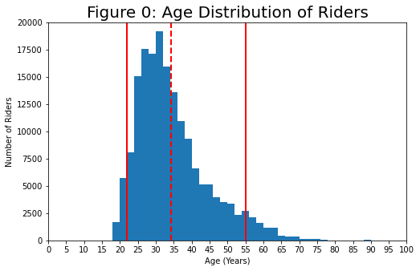

```
The mean = 34.2 Years Old
The 5th Percentile =  22.0 Years old
The 95th Percentile =  55.0 Years old
```

```python
# start with a standard-scaled plot
binsize = 2
bins = np.arange(0, filter2['age'].max()+binsize, binsize)

fig0 = plt.figure(figsize=[8, 5])

plt.hist(filter2['age'], bins = bins)
plt.xlim(0, 100)
plt.ylim(0, 20000)
plt.xticks(np.arange(0, 101, step=5))
plt.xlabel('Age (Years)')
plt.ylabel('Number of Riders')
plt.title('Figure 0: Age Distribution of Riders', fontsize=20)

# help adding mean line to plot
# https://stackoverflow.com/questions/16180946/drawing-average-line-in-histogram-matplotlib
plt.axvline(filter2.age.mean(), color='r', linestyle='dashed', linewidth=2)

# confidence bounds
# help: https://stackoverflow.com/questions/2374640/how-do-i-calculate-percentiles-with-python-numpy
plt.axvline(np.percentile(filter2.age, 95), color='r', linewidth=2)
plt.axvline(np.percentile(filter2.age, 5), color='r', linewidth=2)
plt.show()

# formating help: http://anh.cs.luc.edu/python/hands-on/3.1/handsonHtml/float.html
# the mean and 95% confidence bounds
print('The mean = {:.1f} Years Old'.format(filter2.age.mean()))
# print('The 95th Percentile is {:.1f} and 5th Percentile is {:.1f}'.format((np.percentile(filter2.age, 95)), (np.percentile(filter2.age, 5)))
print('The 5th Percentile = ',np.percentile(filter2.age, 5), 'Years old')
print('The 95th Percentile = ',np.percentile(filter2.age, 95), 'Years old')
```

*Figure 1 Reference* *back to discussion*

### Let's take a look what day is the most popular -- variable(s): `start_day_of_week`

```python
count_days = df_oppertunity.groupby('start_day_of_week')['start_day_of_week'].count().sort_values(ascending=False)
count_days
```

```
start_day_of_week
THU    35176
TUE    31781
WED    29609
FRI    28962
MON    26807
SUN    15503
SAT    15377
Name: start_day_of_week, dtype: int64
```

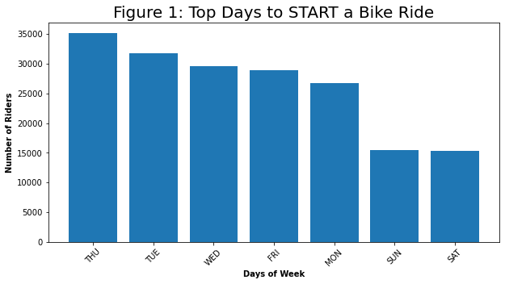

```
Most popular to least popular days to rent bike
 start_day_of_week
THU    35176
TUE    31781
WED    29609
FRI    28962
MON    26807
SUN    15503
SAT    15377
Name: start_day_of_week, dtype: int64
```

```python
# https://www.geeksforgeeks.org/bar-plot-in-matplotlib/

x = list(count_days.keys())
xloc = count_days

fig1 = plt.figure(figsize = (10,5))

#creating the plot
plt.bar(x, xloc)
plt.xticks(rotation = 45) # Rotates X-Axis Ticks by 45-degrees

plt.title('Figure 1: Top Days to START a Bike Ride', fontsize=20);
plt.xlabel('Days of Week', weight='bold');
plt.ylabel('Number of Riders', weight='bold');

plt.show()

print('Most popular to least popular days to rent bike\n',count_days)
```

*Figure 2 Reference* *back to discussion*

```python
# strip start_hour to just hour portion
df_strip = df_oppertunity
df_strip['hours'] = df_strip['start_hour'].str.slice(stop=2)

count_hours = df_strip.groupby('hours')['hours'].count().sort_values(ascending=False)[:20]
count_hours
```

```
hours
17    21847
08    21041
18    16812
09    15886
16    14150
07    10610
19     9873
15     9163
12     8707
13     8531
10     8354
14     8135
11     7872
20     6472
21     4560
06     3484
22     2915
23     1645
00      925
05      896
Name: hours, dtype: int64
```

```python
# https://www.geeksforgeeks.org/bar-plot-in-matplotlib/
x = list(count_hours.keys())
xloc = count_hours

fig2 = plt.figure(figsize = (10,5))

#creating the plot
plt.bar(x, xloc)
plt.xticks(rotation = 45) # Rotates X-Axis Ticks by 45-degrees

plt.title('Figure 2: Top Times to START a Bike Ride', fontsize=20);
plt.xlabel('Days of Week', weight='bold');
plt.ylabel('Number of Riders', weight='bold');
plt.axvline(x=4, color='r', linestyle='dashed', linewidth=2)
plt.axvline(x=11, color='r', linestyle='dashed', linewidth=2)
plt.show()

#print('Most popular to least popular START times to rent bike\n',count_hours)
```

[output not shown]

*Figure 3 Reference* *back to discussion*

```python
# strip start_hour to just hour portion
df_strip1 = df_oppertunity
df_strip1['hours'] = df_strip1['end_hour'].str.slice(stop=2)

count_hours1 = df_strip1.groupby('hours')['hours'].count().sort_values(ascending=False)[:20]

#plotting
x = list(count_hours1.keys())
xloc = count_hours1

fig3 = plt.figure(figsize = (10,5))

#creating the plot
plt.bar(x, xloc)
plt.xticks(rotation = 45) # Rotates X-Axis Ticks by 45-degrees

plt.title('Figure 3: Top Times to END a Bike Ride', fontsize=20);
plt.xlabel('Days of Week', weight='bold');
plt.ylabel('Number of Riders', weight='bold');
plt.axvline(x=4, color='r', linestyle='dashed', linewidth=2)
plt.axvline(x=11, color='r', linestyle='dashed', linewidth=2)
plt.show()

#print('Most popular to least popular END times to rent bike\n',count_hours1)
```

[output not shown]

Review these two plots together

```python
display(fig2)
display(fig3)
```

[output not shown]

```python
print('Distribution START Ride Times (Time 24-Hour Clock)\n', count_hours)
print('\nDistribution START Ride Times (Time 24-Hour Clock)\n', count_hours1)
```

```
Distribution START Ride Times (Time 24-Hour Clock)
 hours
17    21847
08    21041
18    16812
09    15886
16    14150
07    10610
19     9873
15     9163
12     8707
13     8531
10     8354
14     8135
11     7872
```

[output cut: 32 more lines]

*Interesting, note that the top 5 times for START and END are the same... riders only using bikes in less than an hour?* *Confirm duration of ride to verify*

*Figure 4 Reference* *back to discussion*

### Let's take a look how long people are riding -- variable(s): `duration_min`

```python
# take a look at stat distribution
df_oppertunity.describe()
```

|  | duration_hr | duration_min | member_birth_year | age |
| --- | --- | --- | --- | --- |
| count | 183215.000000 | 183215.000000 | 183215.000000 | 183215.000000 |
| mean | 0.201639 | 12.098367 | 1895.288475 | 32.607909 |
| std | 0.498633 | 29.917978 | 412.013105 | 12.067822 |
| min | 0.016944 | 1.016667 | 0.000000 | 0.000000 |
| 25% | 0.090278 | 5.416667 | 1979.000000 | 26.000000 |
| 50% | 0.142778 | 8.566667 | 1987.000000 | 31.000000 |
| 75% | 0.221111 | 13.266667 | 1992.000000 | 38.000000 |
| max | 23.734444 | 1424.066667 | 2001.000000 | 99.000000 |

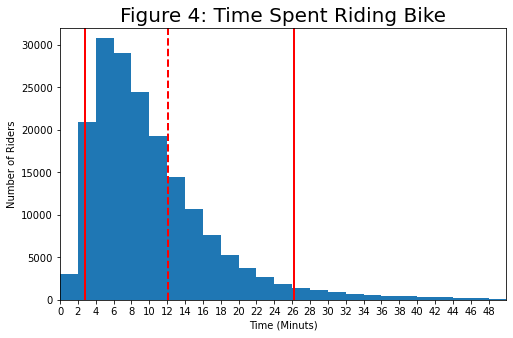

```
The mean = 12.1 minutes
The 5th Percentile = 2.8 minutes long
The 95th Percentile = 26.2 minutes long
```

```python
filter2 = df_oppertunity

# start with a standard-scaled plot
binsize = 2
bins = np.arange(0, filter2['duration_min'].max()+binsize, binsize)

fig4 = plt.figure(figsize=[8, 5])

plt.hist(filter2['duration_min'], bins = bins)
plt.xlim(0, 50)
plt.ylim(0, 32000)
plt.xticks(np.arange(0, 50, step=2))
plt.xlabel('Time (Minuts)')
plt.ylabel('Number of Riders')
plt.title('Figure 4: Time Spent Riding Bike', fontsize=20)
plt.xticks(rotation = 0) # Rotates X-Axis Ticks by 45-degrees

# help adding mean line to plot
# https://stackoverflow.com/questions/16180946/drawing-average-line-in-histogram-matplotlib
plt.axvline(filter2.duration_min.mean(), color='r', linestyle='dashed', linewidth=2)

# confidence bounds
# help: https://stackoverflow.com/questions/2374640/how-do-i-calculate-percentiles-with-python-numpy
plt.axvline(np.percentile(filter2.duration_min, 95), color='r', linewidth=2)
plt.axvline(np.percentile(filter2.duration_min, 5), color='r', linewidth=2)
plt.show()

# formating help: http://anh.cs.luc.edu/python/hands-on/3.1/handsonHtml/float.html
# the mean and 95% confidence bounds
print('The mean = {:.1f} minutes'.format(filter2.duration_min.mean()))
# print('The 95th Percentile is {:.1f} and 5th Percentile is {:.1f}'.format((np.percentile(filter2.age, 95)), (np.percentile(filter2.age, 5)))
#the5th = np.percentile(filter2.duration_min, 5)
print('The 5th Percentile = {:.1f} minutes long'.format(np.percentile(filter2.duration_min, 5)))
print('The 95th Percentile = {:.1f} minutes long'.format(np.percentile(filter2.duration_min, 95)))
```

```python
print('Distribution of Ride Duration - UNFILTERED\n', filter2.duration_min.describe())
```

```
Distribution of Ride Duration - UNFILTERED
 count    183215.000000
mean         12.098367
std          29.917978
min           1.016667
25%           5.416667
50%           8.566667
75%          13.266667
max        1424.066667
Name: duration_min, dtype: float64
```

```python
filter_30min = filter2[filter2['duration_min'] < 30]
print('Distribution of Ride Duration - FILTERED\n', filter_30min.duration_min.describe())
```

```
Distribution of Ride Duration - FILTERED
 count    176457.000000
mean          9.570218
std           5.631750
min           1.016667
25%           5.316667
50%           8.316667
75%          12.566667
max          29.983333
Name: duration_min, dtype: float64
```

## 5.3 Exploration - Bivariate Exploration

[Table of Contents]

[#5 Data Exporation]

[#6 Discussion]  
--- [6.3 Discussion - Bivariate Exploration]

Review of the comparisons of the following variables:

1. Gender vs Age
2. Gender vs Duration of ride

These would be interesting to explore so we can exam the type of population of people are renting our bikes regularly. This could help marketing create more targeted ads.

*Figure 5 Reference* *back to discussion*

### Gender vs Age

```python
# create new df reference for prototyping
filter1 = df_oppertunity

# remove zeros from age data
filter2 = filter1[filter1['age'] > 1]

genderVSage = filter2.groupby('member_gender')['age'].count().sort_values(ascending=False)
genderVSage.head(5)
```

```
member_gender
Male      130443
Female     40791
Other       3646
Name: age, dtype: int64
```

```python
fig5 = plt.figure(figsize = (8, 5))

sns.boxplot(y='age', x='member_gender', data=filter2)

plt.xlabel('Gender')
plt.ylabel('Age (Years)')
plt.title('Figure 5: Age Distribution of Different Genders', fontsize=20)
plt.xticks(rotation = 0) # Rotates X-Axis Ticks by 45-degrees

yMin = 0
yMax = 101
plt.ylim(yMin, yMax)
plt.yticks(np.arange(yMin, yMax, step=5))
# help: https://stats.stackexchange.com/questions/3476/how-to-name-the-ticks-in-a-python-matplotlib-boxplot
plt.xticks([0, 1, 2], ['Male', 'Female', 'Other']) # Needs review

# help adding mean line to plot
# https://stackoverflow.com/questions/16180946/drawing-average-line-in-histogram-matplotlib
plt.axhline(filter2.age.mean(), color='r', linestyle='dashed', linewidth=2)

# confidence bounds
# help: https://stackoverflow.com/questions/2374640/how-do-i-calculate-percentiles-with-python-numpy
plt.axhline(np.percentile(filter2.age, 95), color='r', linewidth=2)
plt.axhline(np.percentile(filter2.age, 5), color='r', linewidth=2)

# text location and annotation notes
# help: https://stackoverflow.com/questions/42877747/add-a-label-to-y-axis-to-show-the-value-of-y-for-a-horizontal-line-in-matplotlib
# https://matplotlib.org/3.1.0/tutorials/text/text_intro.html
plt.text(-0.25, 5, 'Red Lines are represent mean and 95% confidence bounds of Population',
         style='italic', bbox={'facecolor': 'red', 'alpha': 0.5, 'pad': 5})

plt.show()
```

[output not shown]

*Figure 6 Reference* *back to discussion*

### Gender vs Duration

```python
# leverage data frame from 'Gender vs Age'

# remove minutes OVER 30min, based on distrubtion data before
assert filter_30min.duration_min.max() < 31, "There's ride duration data that is NOT under 30 mins!"


# remove zeros from age data
filter_30min_genderZero = filter_30min[filter_30min.member_gender.str.contains(r'[MaleFemaleOther]')]

genderVSduration = filter_30min_genderZero.groupby('member_gender')['duration_min'].count().sort_values(ascending=False)
genderVSduration.head(5)
```

```
member_gender
Male      126421
Female     39105
Other       3402
Name: duration_min, dtype: int64
```

```python
fig6 = plt.figure(figsize = (8, 5))

sns.boxplot(y='duration_min', x='member_gender', data=filter_30min_genderZero)

plt.xlabel('Gender')
plt.ylabel('Duration of Ride (Minutes)')
plt.title('Figure 6: Duration of Ride Distribution of Different Genders', fontsize=20)
plt.xticks(rotation = 0) # Rotates X-Axis Ticks by 45-degrees

yMin = 0
yMax = 31
plt.ylim(yMin, yMax)
plt.yticks(np.arange(yMin, yMax, step=2))
# help: https://stats.stackexchange.com/questions/3476/how-to-name-the-ticks-in-a-python-matplotlib-boxplot
plt.xticks([0, 1, 2], ['Male', 'Female', 'Other']) # Needs review

# help adding mean line to plot
# https://stackoverflow.com/questions/16180946/drawing-average-line-in-histogram-matplotlib
plt.axhline(filter_30min_genderZero.duration_min.mean(), color='r', linestyle='dashed', linewidth=2)

# help: https://matplotlib.org/3.1.0/tutorials/text/text_intro.html
plt.text(-0.25, -5.5, 'Red Lines are represent mean and 95% confidence bounds of Population',
         style='italic', bbox={'facecolor': 'red', 'alpha': 0.5, 'pad': 5})

# confidence bounds
# help: https://stackoverflow.com/questions/2374640/how-do-i-calculate-percentiles-with-python-numpy
plt.axhline(np.percentile(filter_30min_genderZero.duration_min, 5), color='r', linewidth=2)
plt.axhline(np.percentile(filter_30min_genderZero.duration_min, 95), color='r', linewidth=2)

plt.show()
```

[output not shown]

Review these two plots together

```python
display(fig5)
display(fig6)
```

[output not shown]

```python
print('Distribution of Ride Duration - UNFILTERED\n\n', filter2.duration_min.describe())

print('\n-----Quick Note-----')
print('However, note that the 95 Percentile Ride Duration = {:.1f} minutes.'.format(np.percentile(filter2.duration_min, 95)))
print('Therefore data trimmed to 30 mins because it more sensible/practical statistics than 1409 mins (about 23 hours)')
print('     i.e., "data will makes more sense"')
print('--------------------')
print('\nDistribution of Ride Duration - FILTERED\n\n', filter_30min_genderZero.duration_min.describe())
```

```
Distribution of Ride Duration - UNFILTERED

 count    174880.000000
mean         11.733706
std          27.375248
min           1.016667
25%           5.383333
50%           8.500000
75%          13.150000
max        1409.133333
Name: duration_min, dtype: float64

-----Quick Note-----
However, note that the 95 Percentile Ride Duration = 25.5 minutes.
Therefore data trimmed to 30 mins because it more sensible/practical statistics than 1409 mins (about 23 hours)
     i.e., "data will makes more sense"
--------------------

Distribution of Ride Duration - FILTERED

 count    168928.000000
mean          9.521439
std           5.607806
min           1.016667
25%           5.283333
50%           8.266667
75%          12.516667
max          29.983333
Name: duration_min, dtype: float64
```

## 5.4 Exploration - Multivariate Exploration

[Table of Contents]

[#5 Data Exporation]

[#6 Discussion]  
--- [6.4 Discussion - Multivariate Exploration]

*Figure 7 Reference* *back to discussion*

### SUBSCRIBERS vs NON-SUBSCRIBERS - Distribution of Days and Time Bikes Rented the Most

Let's check out which riders were SUBSCRIBERS vs NON-SUBSCRIBERS, but considering the START-TIME and DAY-OF-WEEK rides completed.

Variables of interest:

1. `user_type` Customer vs Subscriber
2. `start_day_of_week` MON-FRI
3. `start_hour` 00-23 (24 hour period)

```python
# help: https://github.com/dirkkadijk/Ford-GoBike-Data-Exploration-and-Communication-of-insights/blob/master/1_exploration_GoBikes_by_DirkKadijk1.0.ipynb
```

```python
df.dtypes
```

```
start_month                 object
end_month                   object
start_day_of_week           object
end_day_of_week             object
start_day                   object
end_day                     object
start_hour                  object
end_hour                    object
start_time                  object
end_time                    object
duration_hr                float64
duration_min               float64
duration_sec                 int64
start_station_id           float64
start_station_name          object
start_station_latitude     float64
start_station_longitude    float64
end_station_id             float64
end_station_name            object
end_station_latitude       float64
end_station_longitude      float64
bike_id                      int64
user_type                   object
member_birth_year            int64
age                          int64
member_gender               object
bike_share_for_all_trip     object
dtype: object
```

```python
# get data and quick cleaning
# make a copy for futher manipulation
df_multivariate = df[['user_type', 'start_day_of_week', 'end_day_of_week',
                     'start_hour', 'end_hour', 'member_gender' ]].copy()
df_multivariate.head(2)
```

|  | user_type | start_day_of_week | end_day_of_week | start_hour | end_hour | member_gender |
| --- | --- | --- | --- | --- | --- | --- |
| 0 | Customer | THU | FRI | 17:32:10.145000 | 08:01:55.975000 | Male |
| 1 | Customer | THU | FRI | 18:53:21.789000 | 06:42:03.056000 | 0 |

```python
# high-level overview of data shape and composition
print('\n----Shape of File (row, column)---\n')
print(df_multivariate.shape)
print('\n----Data Types---\n')
print(df_multivariate.dtypes)
print('\n----Unique Values---\n')
print(df_multivariate.nunique())
print('\n----Number of missing values---\n')
print(df_multivariate.isnull().sum())
```

```
----Shape of File (row, column)---

(183215, 6)

----Data Types---

user_type            object
start_day_of_week    object
end_day_of_week      object
start_hour           object
end_hour             object
member_gender        object
dtype: object

----Unique Values---

user_type                 2
start_day_of_week         7
end_day_of_week           7
start_hour           182884
end_hour             182853
member_gender             4
dtype: int64

----Number of missing values---

user_type            0
start_day_of_week    0
end_day_of_week      0
start_hour           0
end_hour             0
member_gender        0
dtype: int64
```

```python
# strip start_hour to just hour portion
df_multivariate['hours'] = df_multivariate['start_hour'].str.slice(stop=2)
```

```python
# help categorical data
# https://stackoverflow.com/questions/47255746/change-order-on-x-axis-for-matplotlib-chart
# https://pandas.pydata.org/pandas-docs/stable/user_guide/categorical.html

df_multivariate['ORDERED_DAYS'] = pd.Categorical(df_multivariate['start_day_of_week'],
                                           categories=["SAT", "FRI", "THU", "WED", "TUES", "MON", "SUN"], ordered=True)
df_multivariate.head(2)
```

|  | user_type | start_day_of_week | end_day_of_week | start_hour | end_hour | member_gender | hours | ORDERED_DAYS |
| --- | --- | --- | --- | --- | --- | --- | --- | --- |
| 0 | Customer | THU | FRI | 17:32:10.145000 | 08:01:55.975000 | Male | 17 | THU |
| 1 | Customer | THU | FRI | 18:53:21.789000 | 06:42:03.056000 | 0 | 18 | THU |

```python
# color pallet help:
# https://matplotlib.org/3.1.0/tutorials/colors/colormaps.html
# color blindness considerations:
# https://www.tableau.com/about/blog/2016/4/examining-data-viz-rules-dont-use-red-green-together-53463#:~:text=Use%20a%20colorblind%2Dfriendly%20palette%20when%20appropriate&text=For%20example%2C%20blue%2Forange%20is,blue%20to%20someone%20with%20CVD.
fig7 = plt.figure(figsize=(15,10))

plt.subplot(2, 1, 1)
customers = df_multivariate.query('user_type == "Customer"')
count1 = customers.groupby(['ORDERED_DAYS', 'hours']).size()
count1 = count1.reset_index(name='count')
count1 = count1.pivot(index='ORDERED_DAYS', columns='hours', values='count')

# make plot blue/orange for folks that may be color blind
sns.heatmap(count1, cmap="Oranges");
plt.title('CUSTOMER', loc='right', fontsize=15);
plt.xlabel('Time Rented (24-hour Clock)', fontsize=10);
plt.ylabel('Day of week', fontsize=10);
plt.yticks(rotation = 45) # Rotates Axis Ticks

plt.subplot(2, 1, 2)
subscribers = df_multivariate.query('user_type == "Subscriber"')
count2 = subscribers.groupby(['ORDERED_DAYS', 'hours']).size()
count2 = count2.reset_index(name='count')
count2 = count2.pivot(index='ORDERED_DAYS', columns='hours', values='count')

# make plot blue/orange for folks that may be color blind
sns.heatmap(count2, cmap="Blues");
plt.title('SUBSCRIBER', loc='right', fontsize=15);
plt.xlabel('Time Rented (24-hour Clock)', fontsize=10);
plt.ylabel('Day of week', fontsize=10);
plt.yticks(rotation = 45) # Rotates Axis Ticks

plt.subplots_adjust(top=0.91)
plt.suptitle('Figure 7: Customer Subscription Type Review - Analysis of Day and Time Bikes Services Used', fontsize=20);
```

[output not shown]

*Figure 8 Reference* *back to discussion*

### MALE vs FEMALE vs OTHER - Distribution of Days and Time Bikes Rented the Most

Let's check out which riders and their declared gender, but considering the START-TIME and DAY-OF-WEEK rides completed.

Variables of interest:

1. `member_gender` Male vs Female vs Other
2. `start_day_of_week` MON-FRI
3. `start_hour` 00-23 (24 hour period)

```python
# remove zeros from age data
df_multivariate_genderZero = df_multivariate[df_multivariate.member_gender.str.contains(r'[MaleFemaleOther]')]
df_multivariate_genderZero.head(2)
```

|  | user_type | start_day_of_week | end_day_of_week | start_hour | end_hour | member_gender | hours | ORDERED_DAYS |
| --- | --- | --- | --- | --- | --- | --- | --- | --- |
| 0 | Customer | THU | FRI | 17:32:10.145000 | 08:01:55.975000 | Male | 17 | THU |
| 2 | Customer | THU | FRI | 12:13:13.218000 | 05:24:08.146000 | Male | 12 | THU |

```python
# color pallet help:
# https://matplotlib.org/3.1.0/tutorials/colors/colormaps.html
# color blindness considerations:
# https://www.tableau.com/about/blog/2016/4/examining-data-viz-rules-dont-use-red-green-together-53463#:~:text=Use%20a%20colorblind%2Dfriendly%20palette%20when%20appropriate&text=For%20example%2C%20blue%2Forange%20is,blue%20to%20someone%20with%20CVD.
fig8 = plt.figure(figsize=(15,15))

######FIRST SUBPLOT#######
plt.subplot(3, 1, 1)
customers = df_multivariate_genderZero.query('member_gender == "Male"')
count1 = customers.groupby(['ORDERED_DAYS', 'hours']).size()
count1 = count1.reset_index(name='count')
count1 = count1.pivot(index='ORDERED_DAYS', columns='hours', values='count')

# make plot blue/orange for folks that may be color blind
sns.heatmap(count1, cmap="Oranges");
plt.title('MALE', loc='right', fontsize=15);
plt.xlabel('Time Rented (24-hour Clock)', fontsize=10);
plt.ylabel('Day of week', fontsize=10);
plt.yticks(rotation = 45) # Rotates Axis Ticks

######SECOND SUBPLOT#######
plt.subplot(3, 1, 2)
subscribers = df_multivariate_genderZero.query('member_gender == "Female"')
count2 = subscribers.groupby(['ORDERED_DAYS', 'hours']).size()
count2 = count2.reset_index(name='count')
count2 = count2.pivot(index='ORDERED_DAYS', columns='hours', values='count')

# make plot blue/orange for folks that may be color blind
sns.heatmap(count2, cmap="Blues");
plt.title('FEMALE', loc='right', fontsize=15);
plt.xlabel('Time Rented (24-hour Clock)', fontsize=10);
plt.ylabel('Day of week', fontsize=10);
plt.yticks(rotation = 45) # Rotates Axis Ticks

######THIRD SUBPLOT#######
plt.subplot(3, 1, 3)
customers = df_multivariate_genderZero.query('member_gender == "Other"')
count1 = customers.groupby(['ORDERED_DAYS', 'hours']).size()
count1 = count1.reset_index(name='count')
count1 = count1.pivot(index='ORDERED_DAYS', columns='hours', values='count')

# make plot blue/orange for folks that may be color blind
sns.heatmap(count1, cmap="Greens");
plt.title('OTHER', loc='right', fontsize=15);
plt.xlabel('Time Rented (24-hour Clock)', fontsize=10);
plt.ylabel('Day of week', fontsize=10);
plt.yticks(rotation = 45) # Rotates Axis Ticks

#############
plt.subplots_adjust(top=0.93)
plt.suptitle('Figure 8: Gender Type Review - Analysis of Day and Time Bikes Services Used', fontsize=20);
```

[output not shown]

Review these SUBSCRIPTIONS and GENDER heatmaps together

```python
display(fig7)
print('===============================')
display(fig8)
```

[output not shown]

##### 📊 Data Exploration END ➜ Discussion START 📊

# 6. DISCUSSION

[Table of Contents]

[#5 Data Exporation]  
--- [Preliminary Review] --- [Univariate Exploration] --- [Bivariate Exploration] --- [Multivariate Exploration]

[#6 Discussion]  
--- [Preliminary Review] --- [Univariate Exploration] --- [Bivariate Exploration] --- [Multivariate Exploration]

## 6.1 Discussion - Preliminary Wrangling

[Table of Contents]

[#5 Data Exporation]  
--- [5.1 Exploration - Preliminary Review]

[#6 Discussion]

```python
# Applicable data for reference
# high-level overview of data shape and composition
print('\n----Shape of File (row, column)---\n')
print(df.shape)
print('\n----Data Types---\n')
print(df.dtypes)
print('\n----Unique Values---\n')
print(df.nunique())
print('\n----Number of missing values---\n')
print(df.isnull().sum())
```

```
----Shape of File (row, column)---

(183215, 27)

----Data Types---

start_month                 object
end_month                   object
start_day_of_week           object
end_day_of_week             object
start_day                   object
end_day                     object
start_hour                  object
end_hour                    object
start_time                  object
end_time                    object
duration_hr                float64
duration_min               float64
duration_sec                 int64
start_station_id           float64
start_station_name          object
start_station_latitude     float64
start_station_longitude    float64
end_station_id             float64
end_station_name            object
end_station_latitude       float64
end_station_longitude      float64
bike_id                      int64
user_type                   object
member_birth_year            int64
age                          int64
member_gender               object
bike_share_for_all_trip     object
dtype: object

----Unique Values---

start_month                     1
end_month                       2
start_day_of_week               7
```

[output cut: 41 more lines]

```
start_station_id           0
start_station_name         0
start_station_latitude     0
start_station_longitude    0
end_station_id             0
end_station_name           0
end_station_latitude       0
end_station_longitude      0
bike_id                    0
user_type                  0
member_birth_year          0
age                        0
member_gender              0
bike_share_for_all_trip    0
dtype: int64
```

### What is the structure of your dataset?

There are 183,215 ride entries in the dataset with 27 features (see above for details). Most variables are categorical in nature (specifically a data type of string). Data extraction of date, date day, and time (hr, min, etc.) was broken apart from the `start_time` and `end_time`.

### What is/are the main feature(s) of interest in your dataset?

I'm most interested in figuring out critical times and dates which high frequency of customers is expected. Thus, allowing strategies to be developed to create targeted marketing and lean staffing schedules.

### What features in the dataset do you think will help support your investigation into your feature(s) of interest?

The following features that will have the strongest effect in developing these strategies is by analyzing

1. Age
2. Gender
3. Ride duration
4. Days bikes rented
5. Times bikes rented

*New features were created for time and date as required. The final cleaned and tidied data was exported as a `master.csv` file, then read back into the report as a `df`.*

### **Please note to reader, details of any cleaning or tidying of the dataset can be seen in Section 2 - Assessing Data (Cleaning and Tidying)**

## 6.2 Discussion - Univariate Exploration

[Table of Contents]

[#5 Data Exporation]  
--- [5.2 Exploration - Univariate Exploration]

[#6 Discussion]

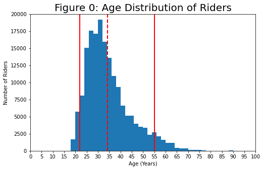

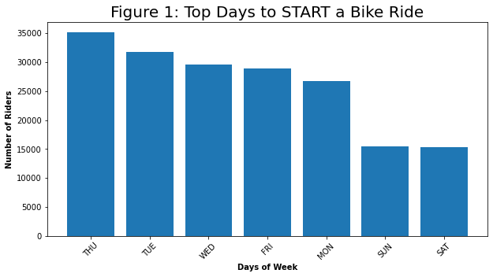

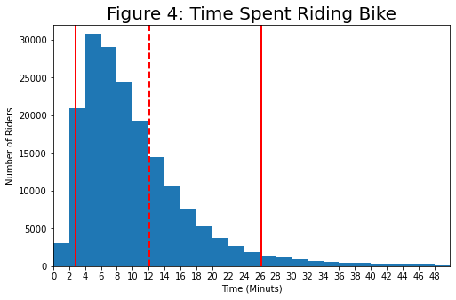

```python
# Applicable data for reference Figures 0-4
display(fig0)
print('====================================================================================================')
display(fig1)
print('====================================================================================================')
display(fig2)
print('====================================================================================================')
display(fig3)
print('====================================================================================================')
display(fig4)
```

### **Please note to reader, details of any cleaning or tidying of the dataset can be seen in Section 2 - Assessing Data (Cleaning and Tidying)**

### Discuss the distribution(s) of your variable(s) of interest. (1) Were there any unusual points? (2) Did you need to perform any transformations?

Figure 0 - Age Distribution of Riders

Figure 1 - Top Days to START a Bike Ride

1. The day of the week was reviewed to determine what day had the highest in flux of customers. Most notably Tuesday through Thursday were the most popular days to rent bikes--Thursday being the most with 35176 customers overall. Conversely, Saturday through Monday were the least--Saturday being the least with 15,377 customers.
2. No transformations additional transformations was required for the data analysis.

Figure 2 - Top Times to START a Bike Ride

Figure 3 - Top Times to END a Bike Ride

1. Interestingly, the data distribution was almost the same as shown in Figure 2. The only difference in order was between, while data was sorted max to min, column 6 to column 11 (as shown by the red lines on the bar chart). This indicates that the time of rides were typically completed within the same hour.
2. No transformations additional transformations was required for the data analysis.

Figure 4 - Time Spent Riding Bike

1. This analysis was a verification step to the posit stated from the discussion of Figure 3. Figure 4 confirms that most ride durations on average was about 12.1 minutes long. The 5th percentile ride duration being 2.8 minutes, and the 95th percentile ride duration being 26.2 minutes.
2. No transformations additional transformations was required for the data analysis.

### Of the features you investigated, (1) were there any unusual distributions? (2) Did you perform any operations on the data to tidy, adjust, or change the form of the data? If so, why did you do this?

Figure 0 - Age Distribution of Riders

1. There was ages with "0 years old" and also astronomically old ages calculated.
2. Data was filtered to remove ages less than 1 years hold and trimmed to 100 year old (based on research of the [2010 U.S. Census Bureu](https://www.census.gov/prod/cen2010/briefs/c2010br-03.pdf)). Ages with 0 years old calculated is unlikely to have the ability to ride a bike... This was supported by the fact that the 5th percentile rider's age was 22 years old. Additionally, for the scope of this report 100 years old was chosen based on the fact that the 95th percentile rider's age was 55 years old.

Figure 1 - Top Days to START a Bike Ride

1. It was unusual to see the weekend (Sat and Sun) as the lowest count of customers. As compared to Thursday, which is in the middle of the work week--perhaps the job title of customer should be collected to understand if customers are "working professionals" vs "students".
2. No additional cleaning was required for the dataset after initial cleaning, details shown in **Section 2 - Assessing Data (Cleaning and Tidying)**

Figure 2 - Top Times to START a Bike Ride

1. The top 5 times to rent bikes, in order: 5pm, 8am, 6pm, 9am, and 4pm. So looking at this dataset from a different perspective, popular morning times were between 8am-9am, then later in the afternoon/evening popular times were between 4pm-6pm.
2. Additional cleaning of the time data was required. Initially this data was set as a string. The time string was then stripped to its hour portion.

Figure 3 - Top Times to END a Bike Ride

1. Similarly, the data distribution was almost the same as shown in Figure 2. The only difference in order was between, while data was sorted max to min, column 6 to column 11 (as shown by the red lines on the bar chart).
2. Additional cleaning of the time data was required. Initially this data was set as a string. The time string was then stripped to its hour portion. This indicates that the time of rides were typically completed within the same hour.

Figure 4 - Time Spent Riding Bike

1. When review the feature of time, hours was not reviewed in greater detail because Figure 4 confirms that most ride durations on average was about 12.1 minutes long. In fact, the 5th percentile ride duration being 2.8 minutes, and the 95th percentile ride duration being 26.2 minutes. Therefore, it was more meaningful to do a distribution of ride duration as minutes instead of hours.
2. No additional cleaning was required for the dataset after initial cleaning, details shown in **Section 2 - Assessing Data (Cleaning and Tidying)**

*List of Figures - Detailed analysis to create plots and statistics (Click below)*

- Figure 0 - Age Distribution of Riders
- Figure 1 - Top Days to START a Bike Ride
- Figure 2 - Top Times to START a Bike Ride
- Figure 3 - Top Times to END a Bike Ride
- Figure 4 - Time Spent Riding Bike

## 6.3 Discussion - Bivariate Exploration

[Table of Contents]

[#5 Data Exporation]  
--- [5.3 Exploration - Bivariate Exploration]

[#6 Discussion]

```python
# Applicable data for reference Figures 5-6
display(fig5)
print('====================================================================================================')
display(fig6)
```

[output not shown]

### Talk about some of the relationships you observed in this part of the investigation. How did the feature(s) of interest vary with other features in the dataset?

First, it was interesting to note that the few customers that identified their gender indicated a gender of "other". However, the data scientist respects the gender identity of those participating in the bike renting service.

When reviewing gender to the age of the customer population, as shown in Figures 5, there appears no discernable difference between the different genders. The female population may be representative of the total mean of about 35 years old, and slightly higher when compared to male and other classifications. However, a t-test is required to confirm if these differences are statistically significant.

When reviewing gender to the ride duration population, as shown in Figures 6, similarities in spread between female and other classifications was noted. Average ride time between female and other classifications being about 9.5 minutes. When comparing to the male population, the male group tended to have shorter rides. However, a standard t-test would need to be performed for confirmation.

### Did you observe any interesting relationships between the other features (not the main feature(s) of interest)?

Other features, such as location of where bikes were rented was out of scope for this report. Therefore, exploratory analysis only focused on the feature(s) of interest--as stated at the beginning of the analysis.

*List of Figures - Detailed analysis to create plots and statistics (Click below)*

- Figure 5 - Age Distribution of Different Genders
- Figure 6 - Duration of Ride Distribution of Different Genders

## 6.4 Discussion - Multivariate Exploration

[Table of Contents]

[#5 Data Exporation]  
--- [5.4 Exploration - Multivariate Exploration]

[#6 Discussion]

```python
# Applicable data for reference Figures 7-8
display(fig7)
print('====================================================================================================')
display(fig8)
```

[output not shown]

### Talk about some of the relationships you observed in this part of the investigation. Were there features that strengthened each other in terms of looking at your feature(s) of interest?

The observations noted above is applicable to both customer (non-subscriber) and subscriber riders. The only difference notated was that customer (or non-subscribers) tend to rent bikes more frequently on the weekends (Saturday and Sunday) as opposed to riders with a subscription.

### Were there any interesting or surprising interactions between features?

Taking the extension of this analysis above and applying it to the identified genders in this study indicates similar heatmaps between males and females, as shown in Figure 8. The male and female heatmap, compared to Figure 7, tend to follow the heatmap pattern of a subscriber identification. The other gender classification tended to be more spread and did not have the same heatmap shape of the males and females. This may indicate that the other classification is a part of both the non-subscriber and subscriber identification groups. This observation can be explored further in a future analysis of the data.

*List of Figures - Detailed analysis to create plots and statistics (Click below)*

##### 🍻 Discussion END ➜ Conclusion START 🍻

# 7. CONCLUSION

[Table of Contents]

[#5 Data Exporation]  
--- [Preliminary Review] --- [Univariate Exploration] --- [Bivariate Exploration] --- [Multivariate Exploration]

[#6 Discussion]  
--- [Preliminary Review] --- [Univariate Exploration] --- [Bivariate Exploration] --- [Multivariate Exploration]

*List of Figures - Detailed analysis to create plots and statistics (Click below)*

##### 🏁 Conclusion END -- Project FINALE 🏁

# End of Data Project!

Made with ❤️ by Jhon!

Further impovements include...

1. Validation statements using `assert` clauses to confirm that data manipuation is correct during cleaning stage
2. More plots exploring data
3. Adding helpful annotations to plots
4. Hypothesis Testing, to determine the statisticaly significance of various features (age, gender, etc.) to determine if different times/dates affect customer interaction
5. Multivariate and univariate comparison and confirmation

[Table of Contents]